# Project 1: Wrangling, Exploration, Visualization

SDS322E, David Yang

11/1/2021

## Data Wrangling, Exploration, Visualization

### David Yang dy4652

#### Introduction

The first dataset, uniSalaries, shows average salaries from different universities in the USA. The salaries are split by percentiles as well as median. The universities are categorized into what “type” of school they are. The second dataset, uniRanks, displays universities’ rankings gathered from The Center for World University Ranking. Universities are ranked in several different criteria in on a national scale, with 1 being the best. Both datasets were acquired through Kaggle. As someone who has been through the college admissions process and might do so again in the future, I thought of this as a fun/interesting dataset to analyze and it would be interesting to see how salaries and school type may align with school ranking. The data is not perfect since data is gathered from different times, but the year gap is at most a couple of years so I thought the results would still be relevant. I performed some modifications to the data before “tidying” and joining to include moer data and filter out irrelevant info.

```r
library(tidyverse)
library(gt)
uniSalaries <- read.csv("collegeSalaries.csv")
uniRanks <- read.csv("cwurData.csv")
uniSalaries <- uniSalaries %>% rename(institution = School.Name)
uniSalaries <- uniSalaries %>% mutate(institution = str_replace(institution,
    " \\(.+\\)", ""))
uniRanks <- uniRanks %>% filter(year == 2015)
uniRanks <- uniRanks %>% select(-c(country, year))
```

#### Tidying: Reshaping

```r
uniSalaries <- uniSalaries %>% pivot_longer(3:8, names_to = "percentile",
    values_to = "salary") %>% mutate(percentile = str_replace(percentile,
    "Career.", "")) %>% separate(percentile, into = c("career_stage",
    "percentile"), sep = "\\.")
uniSalaries <- uniSalaries %>% mutate(salary = str_replace(salary,
    "\\$", "")) %>% mutate(salary = str_replace(salary, ",",
    "")) %>% mutate(salary = as.numeric(salary)) %>% mutate(School.Type = as.character(School.Type))
```

Since salary percentile/median and career time were 2 variables that were spread throughout the columns in uniSalaries, I decided to pivot these into their own columns with the value for “career_stage” being either mid or starting, and the “percentile” column being one of the percentiles or the median.

#### Joining/Merging

```r
uniSalaries %>% nrow()
```

```
## [1] 1614
```

```r
uniSalaries %>% n_distinct
```

```
## [1] 1614
```

```r
uniSalaries %>% distinct(institution)
```

```
## # A tibble: 249 × 1
##    institution
##    <chr>
##  1 Massachusetts Institute of Technology
##  2 California Institute of Technology
##  3 Harvey Mudd College
##  4 Polytechnic University of New York, Brooklyn
##  5 Cooper Union
##  6 Worcester Polytechnic Institute
##  7 Carnegie Mellon University
##  8 Rensselaer Polytechnic Institute
##  9 Georgia Institute of Technology
## 10 Colorado School of Mines
## # … with 239 more rows
```

```r
uniRanks %>% nrow()
```

```
## [1] 1000
```

```r
uniRanks %>% n_distinct
```

```
## [1] 1000
```

```r
uniRanks %>% left_join(uniSalaries) %>% filter(is.na(School.Type)) %>%
    distinct(institution)
```

```
##                                           institution
## 1                                 Stanford University
## 2                             University of Cambridge
## 3                                University of Oxford
## 4                               University of Chicago
## 5                                 University of Tokyo
## 6               University of California, Los Angeles
## 7                            Johns Hopkins University
## 8                                    Kyoto University
## 9                                 New York University
## 10                  University of Michigan, Ann Arbor
## 11    Swiss Federal Institute of Technology in Zurich
## 12                            Northwestern University
## 13                     Hebrew University of Jerusalem
## 14                          Seoul National University
```

[output cut: 87 more lines]

```r
uniSalaries %>% left_join(uniRanks) %>% filter(is.na(world_rank)) %>%
    distinct(institution)
```

```
## # A tibble: 160 × 1
##    institution
##    <chr>
##  1 Harvey Mudd College
##  2 Polytechnic University of New York, Brooklyn
##  3 Cooper Union
##  4 Worcester Polytechnic Institute
##  5 Stevens Institute of Technology
##  6 Wentworth Institute of Technology
##  7 South Dakota School of Mines & Technology
##  8 New Mexico Institute of Mining and Technology
##  9 Embry-Riddle Aeronautical University
## 10 Tennessee Technological University
## # … with 150 more rows
```

```r
merged <- uniSalaries %>% inner_join(uniRanks)
merged %>% distinct(institution)
```

```
## # A tibble: 89 × 1
##    institution
##    <chr>
##  1 Massachusetts Institute of Technology
##  2 California Institute of Technology
##  3 Carnegie Mellon University
##  4 Rensselaer Polytechnic Institute
##  5 Georgia Institute of Technology
##  6 Colorado School of Mines
##  7 Illinois Institute of Technology
##  8 Virginia Polytechnic Institute and State University
##  9 Rochester Institute of Technology
## 10 University of Maryland, College Park
## # … with 79 more rows
```

#### Wrangling

```r
merged %>% mutate(salary_rank = rank(-salary)) %>% arrange(salary_rank)
```

```
## # A tibble: 594 × 17
##    institution             School.Type career_stage percentile salary world_rank
##    <chr>                   <chr>       <chr>        <chr>       <dbl>      <int>
##  1 Yale University         Ivy League  Mid          90th       326000         11
##  2 Dartmouth College       Ivy League  Mid          90th       321000         44
##  3 Harvard University      Ivy League  Mid          90th       288000          1
##  4 University of Pennsylv… Ivy League  Mid          90th       282000         14
##  5 Princeton University    Ivy League  Mid          90th       261000          9
##  6 Columbia University     Ivy League  Mid          90th       241000          6
##  7 Dartmouth College       Ivy League  Mid          75th       234000         44
##  8 Brown University        Ivy League  Mid          90th       228000         83
##  9 Massachusetts Institut… Engineering Mid          90th       220000          3
## 10 Wesleyan University     Liberal Ar… Mid          90th       215000        351
## # … with 584 more rows, and 11 more variables: national_rank <int>,
## #   quality_of_education <int>, alumni_employment <int>,
## #   quality_of_faculty <int>, publications <int>, influence <int>,
## #   citations <int>, broad_impact <int>, patents <int>, score <dbl>,
## #   salary_rank <dbl>
```

```r
merged %>% summarise_if(is_numeric, mean, na.rm = T)
```

```
## # A tibble: 1 × 12
##   salary world_rank national_rank quality_of_education alumni_employment
##    <dbl>      <dbl>         <dbl>                <dbl>             <dbl>
## 1 88239.       323.          108.                 246.              298.
## # … with 7 more variables: quality_of_faculty <dbl>, publications <dbl>,
## #   influence <dbl>, citations <dbl>, broad_impact <dbl>, patents <dbl>,
## #   score <dbl>
```

```r
merged %>% summarise_if(is_numeric, n_distinct)
```

```
## # A tibble: 1 × 12
##   salary world_rank national_rank quality_of_education alumni_employment
##    <int>      <int>         <int>                <int>             <int>
## 1    347         89            89                   51                72
## # … with 7 more variables: quality_of_faculty <int>, publications <int>,
## #   influence <int>, citations <int>, broad_impact <int>, patents <int>,
## #   score <int>
```

```r
merged %>% summarise_if(negate(is_numeric), n_distinct)
```

```
## # A tibble: 1 × 4
##   institution School.Type career_stage percentile
##         <int>       <int>        <int>      <int>
## 1          89           5            2          5
```

```r
merged %>% group_by(School.Type) %>% summarise_if(is_numeric,
    median, na.rm = T)
```

```
## # A tibble: 5 × 13
##   School.Type  salary world_rank national_rank quality_of_educ… alumni_employme…
##   <chr>         <dbl>      <dbl>         <dbl>            <dbl>            <dbl>
## 1 Engineering   96600      256            98              137              142
## 2 Ivy League   103500       10.5           8.5             12.5             16.5
## 3 Liberal Arts  80200      351           124              154               61
## 4 Party         72100      170.           76.5            224.             278
## 5 State         70500      353           125              367              337
## # … with 7 more variables: quality_of_faculty <dbl>, publications <dbl>,
## #   influence <dbl>, citations <dbl>, broad_impact <dbl>, patents <dbl>,
## #   score <dbl>
```

```r
merged %>% group_by(School.Type) %>% filter(percentile == "Median") %>%
    summarise_if(is_numeric, max, na.rm = T)
```

```
## # A tibble: 5 × 13
##   School.Type  salary world_rank national_rank quality_of_educ… alumni_employme…
##   <chr>         <dbl>      <int>         <int>            <int>            <int>
## 1 Engineering  126000        710           196              367              431
## 2 Ivy League   134000         83            50               64               43
## 3 Liberal Arts  97900        351           124              154               61
## 4 Party         95000        460           149              367              455
## 5 State        112000        929           228              367              567
## # … with 7 more variables: quality_of_faculty <int>, publications <int>,
## #   influence <int>, citations <int>, broad_impact <int>, patents <int>,
## #   score <dbl>
```

```r
median_deviate <- function(x) {
    y = mean(x - median(x, na.rm = T), na.rm = T)
    return(y)
}
merged %>% group_by(School.Type, percentile, career_stage) %>%
    summarise_if(is_numeric, median_deviate)
```

```
## # A tibble: 30 × 15
## # Groups:   School.Type, percentile [25]
##    School.Type percentile career_stage salary world_rank national_rank
##    <chr>       <chr>      <chr>         <dbl>      <dbl>         <dbl>
##  1 Engineering 10th       Mid          -1150       -6.11        -10.4
##  2 Engineering 25th       Mid          -1556.      -6.11        -10.4
##  3 Engineering 75th       Mid           -556.      -6.11        -10.4
##  4 Engineering 90th       Mid           2750       -6.11        -10.4
##  5 Engineering Median     Mid            644.      -6.11        -10.4
##  6 Engineering Median     Starting      2300       -6.11        -10.4
##  7 Ivy League  10th       Mid           1550       11.8           6.25
##  8 Ivy League  25th       Mid           2588.      11.8           6.25
##  9 Ivy League  75th       Mid           -375       11.8           6.25
## 10 Ivy League  90th       Mid          -1875       11.8           6.25
## # … with 20 more rows, and 9 more variables: quality_of_education <dbl>,
## #   alumni_employment <dbl>, quality_of_faculty <dbl>, publications <dbl>,
## #   influence <dbl>, citations <dbl>, broad_impact <dbl>, patents <dbl>,
## #   score <dbl>
```

```r
merged %>% summarise_all(funs(sum(is.na(.))))
```

```
## # A tibble: 1 × 16
##   institution School.Type career_stage percentile salary world_rank
##         <int>       <int>        <int>      <int>  <int>      <int>
## 1           0           0            0          0      2          0
## # … with 10 more variables: national_rank <int>, quality_of_education <int>,
## #   alumni_employment <int>, quality_of_faculty <int>, publications <int>,
## #   influence <int>, citations <int>, broad_impact <int>, patents <int>,
## #   score <int>
```

```r
merged %>% filter(str_detect(institution, "Technology")) %>%
    summarise(mean(salary, na.rm = T))
```

```
## # A tibble: 1 × 1
##   `mean(salary, na.rm = T)`
##                       <dbl>
## 1                   105261.
```

```r
merged %>% filter(str_detect(institution, "Technology")) %>%
    gt() %>% tab_header(title = md("**Summary Statistics**"),
    subtitle = md("A table of salary and ranking statistics for univerisites with 'Technology'"))
```

**Summary Statistics**

A table of salary and ranking statistics for univerisites with 'Technology'

| institution | School.Type | career_stage | percentile | salary | world_rank | national_rank | quality_of_education | alumni_employment | quality_of_faculty | publications | influence | citations | broad_impact | patents | score |
| --- | --- | --- | --- | --- | --- | --- | --- | --- | --- | --- | --- | --- | --- | --- | --- |
| Massachusetts Institute of Technology | Engineering | Starting | Median | 72200 | 3 | 3 | 3 | 11 | 2 | 15 | 2 | 2 | 2 | 1 | 97.54 |
| Massachusetts Institute of Technology | Engineering | Mid | Median | 126000 | 3 | 3 | 3 | 11 | 2 | 15 | 2 | 2 | 2 | 1 | 97.54 |
| Massachusetts Institute of Technology | Engineering | Mid | 10th | 76800 | 3 | 3 | 3 | 11 | 2 | 15 | 2 | 2 | 2 | 1 | 97.54 |
| Massachusetts Institute of Technology | Engineering | Mid | 25th | 99200 | 3 | 3 | 3 | 11 | 2 | 15 | 2 | 2 | 2 | 1 | 97.54 |
| Massachusetts Institute of Technology | Engineering | Mid | 75th | 168000 | 3 | 3 | 3 | 11 | 2 | 15 | 2 | 2 | 2 | 1 | 97.54 |
| Massachusetts Institute of Technology | Engineering | Mid | 90th | 220000 | 3 | 3 | 3 | 11 | 2 | 15 | 2 | 2 | 2 | 1 | 97.54 |
| California Institute of Technology | Engineering | Starting | Median | 75500 | 12 | 10 | 6 | 328 | 7 | 53 | 9 | 19 | 25 | 13 | 84.40 |
| California Institute of Technology | Engineering | Mid | Median | 123000 | 12 | 10 | 6 | 328 | 7 | 53 | 9 | 19 | 25 | 13 | 84.40 |
| California Institute of Technology | Engineering | Mid | 10th | NA | 12 | 10 | 6 | 328 | 7 | 53 | 9 | 19 | 25 | 13 | 84.40 |
| California Institute of Technology | Engineering | Mid | 25th | 104000 | 12 | 10 | 6 | 328 | 7 | 53 | 9 | 19 | 25 | 13 | 84.40 |
| California Institute of Technology | Engineering | Mid | 75th | 161000 | 12 | 10 | 6 | 328 | 7 | 53 | 9 | 19 | 25 | 13 | 84.40 |
| California Institute of Technology | Engineering | Mid | 90th | NA | 12 | 10 | 6 | 328 | 7 | 53 | 9 | 19 | 25 | 13 | 84.40 |
| Georgia Institute of Technology | Engineering | Starting | Median | 58300 | 80 | 48 | 135 | 60 | 218 | 107 | 152 | 78 | 106 | 36 | 52.08 |
| Georgia Institute of Technology | Engineering | Mid | Median | 106000 | 80 | 48 | 135 | 60 | 218 | 107 | 152 | 78 | 106 | 36 | 52.08 |
| Georgia Institute of Technology | Engineering | Mid | 10th | 67200 | 80 | 48 | 135 | 60 | 218 | 107 | 152 | 78 | 106 | 36 | 52.08 |
| Georgia Institute of Technology | Engineering | Mid | 25th | 85200 | 80 | 48 | 135 | 60 | 218 | 107 | 152 | 78 | 106 | 36 | 52.08 |
| Georgia Institute of Technology | Engineering | Mid | 75th | 137000 | 80 | 48 | 135 | 60 | 218 | 107 | 152 | 78 | 106 | 36 | 52.08 |
| Georgia Institute of Technology | Engineering | Mid | 90th | 183000 | 80 | 48 | 135 | 60 | 218 | 107 | 152 | 78 | 106 | 36 | 52.08 |
| Illinois Institute of Technology | Engineering | Starting | Median | 56000 | 480 | 154 | 274 | 114 | 218 | 784 | 713 | 511 | 715 | 861 | 44.85 |
| Illinois Institute of Technology | Engineering | Mid | Median | 97800 | 480 | 154 | 274 | 114 | 218 | 784 | 713 | 511 | 715 | 861 | 44.85 |
| Illinois Institute of Technology | Engineering | Mid | 10th | 56100 | 480 | 154 | 274 | 114 | 218 | 784 | 713 | 511 | 715 | 861 | 44.85 |
| Illinois Institute of Technology | Engineering | Mid | 25th | 77400 | 480 | 154 | 274 | 114 | 218 | 784 | 713 | 511 | 715 | 861 | 44.85 |
| Illinois Institute of Technology | Engineering | Mid | 75th | 121000 | 480 | 154 | 274 | 114 | 218 | 784 | 713 | 511 | 715 | 861 | 44.85 |
| Illinois Institute of Technology | Engineering | Mid | 90th | 165000 | 480 | 154 | 274 | 114 | 218 | 784 | 713 | 511 | 715 | 861 | 44.85 |
| Rochester Institute of Technology | Engineering | Starting | Median | 48900 | 710 | 196 | 367 | 431 | 218 | 905 | 643 | 287 | 671 | 587 | 44.35 |
| Rochester Institute of Technology | Engineering | Mid | Median | 84600 | 710 | 196 | 367 | 431 | 218 | 905 | 643 | 287 | 671 | 587 | 44.35 |
| Rochester Institute of Technology | Engineering | Mid | 10th | 45000 | 710 | 196 | 367 | 431 | 218 | 905 | 643 | 287 | 671 | 587 | 44.35 |
| Rochester Institute of Technology | Engineering | Mid | 25th | 62100 | 710 | 196 | 367 | 431 | 218 | 905 | 643 | 287 | 671 | 587 | 44.35 |
| Rochester Institute of Technology | Engineering | Mid | 75th | 112000 | 710 | 196 | 367 | 431 | 218 | 905 | 643 | 287 | 671 | 587 | 44.35 |
| Rochester Institute of Technology | Engineering | Mid | 90th | 159000 | 710 | 196 | 367 | 431 | 218 | 905 | 643 | 287 | 671 | 587 | 44.35 |

First, I created a new column using the salaries column that ranks salaries, with 1 being the highest salary. Perhaps not too surprisingly, most of the highest salaries are in the mid career stage in the ivy leagues, with Yale, Dartmouth, and Harvard taking the top 3 spots. Their 90 percentile salaries are $326,000, $321,000 and $288,000, respectively.

Next, I used summarise_if on the numeric columns to calculate the mean and distinct values. I also found the distinct values for the categorical values as well.

I grouped by school types and found the medians for all the values for each school type. I also grouped by school types and filtered out for only median salaries and found the max values of numeric variables. Ivy league schools unsurprisingly had the highest (lowest #) median ranks in all categories and had the highest median salary. Engineering schools followed in median salary. I created a function called median_deviate that calculates how much less or greater a variable is from its median. I then grouped the data by school type, percentile, and career stage and summarised all the numeric variables using median_deviate.

I calculated all the NA values of each column, of which there are only 2 of in the ‘salary’ column. I filtered out schools only with ‘technology’ in the name and calculated the mean salary, of which it is $105,260.70.

#### Visualizing

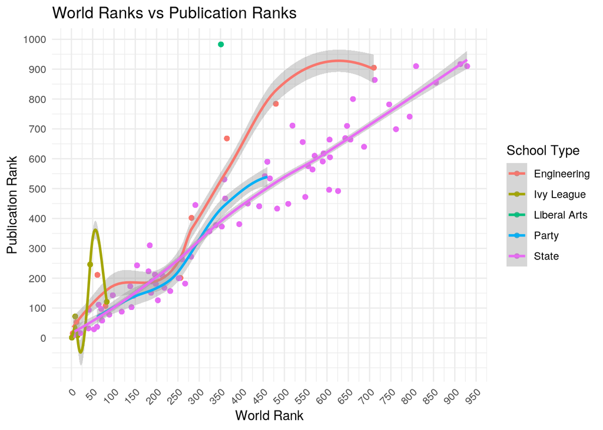

```r
ggplot(merged, aes(x = world_rank, y = publications)) + geom_point(aes(color = School.Type)) +
    geom_smooth(aes(color = School.Type)) + ggtitle("World Ranks vs Publication Ranks") +
    xlab("World Rank") + ylab("Publication Rank") + labs(color = "School Type") +
    scale_y_continuous(breaks = seq(0, 1000, 100)) + theme_minimal() +
    theme(axis.text.x = element_text(angle = 45, hjust = 1)) +
    scale_x_continuous(breaks = seq(0, 1250, 50))
```

Plot 1 shows how world rank correlates with publication rank. For most school types there is an apparent positive correlation between world rank and publication rank. The ivy league school types fluctuate a bit more than the other school types but there is still somewhat of a positive positive correlation. State schools on the other hand fluctuate the least, with world rank and publication rank being quite aligned.

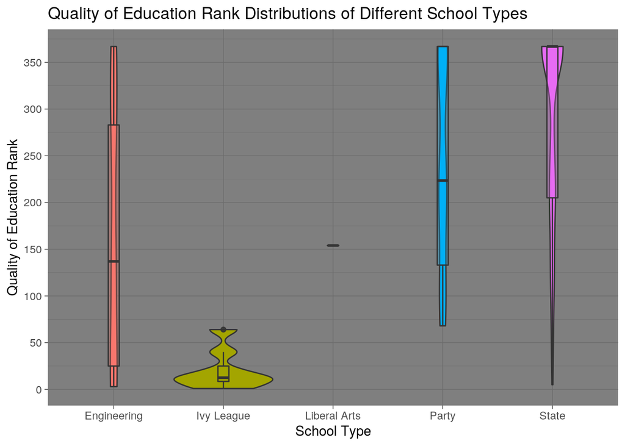

```r
ggplot(merged, aes(x = School.Type, y = quality_of_education,
    fill = School.Type)) + geom_violin() + geom_boxplot(width = 0.1,
    alpha = 0.3) + xlab("School Type") + ylab("Quality of Education Rank") +
    ggtitle("Quality of Education Rank Distributions of Different School Types") +
    scale_y_continuous(breaks = seq(0, 400, 50)) + theme_dark() +
    theme(legend.position = "none")
```

This is a box plot superpositioned over a violin plot showing how the distribution quality of education ranks differ among different schiool types. There is probably not enough data for liberal arts to make any conclusions but most other schools except ivy leauge schools have a wide range in the quality of education rank. Party and state schools tend to have a slight higher distribution in the higher ranks within their range while ivy league schools are more concentrated in the lower ranks of their school type’s range.

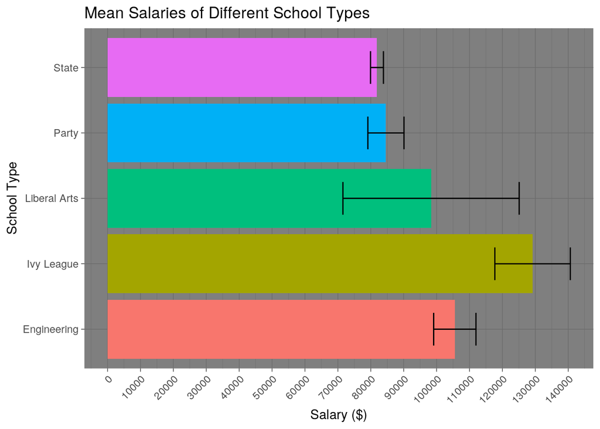

```r
ggplot(merged, aes(x = School.Type, y = salary)) + geom_bar(stat = "summary",
    fun = mean, aes(fill = School.Type)) + geom_errorbar(stat = "summary",
    fun.data = mean_se, width = 0.5) + theme_dark() + theme(legend.position = "none") +
    coord_flip() + xlab("School Type") + ylab("Salary ($)") +
    ggtitle("Mean Salaries of Different School Types") + scale_y_continuous(breaks = seq(0,
    160000, 10000)) + theme(axis.text.x = element_text(angle = 45,
    hjust = 1))
```

This is a horizontal bar plot plotting mean salary vs school type. Ivy leagues unsurprisingly have the highest mean salary and engineering schools unsurprisingly follow it. Liberal art schools have the longest SE mean bar likely due to the lower amount of obversations that are liberal art schools in this merged dataset.

#### Concluding Remarks

Overall, I am not surprised by the results of the data, but it is still interesting to look at the numerical data and figure out how salaries correlate with ranks. I think this data might have been better managed since I am worried that some of the ways I handled the data can lead to fallacious results, but overall I thought it was good practice in applying what I had learned this semester.